## Academic Honesty Statement

**THIS IS AN INDIVIDUAL ASSESSMENT, THIS DOCUMENT AND YOUR ANSWERS ARE FOR YOUR EYES ONLY. ANY VIOLATION OF THIS POLICY WILL BE IMMEDIATELY REPORTED.**

*Replace the underscores below with your name acknowledging that you have read and understood your institution’s academic misconduct policy.*

I, Jeremy Miranda, hereby state that I have not communicated with or gained information in any way from my classmates or anyone other than the Professor or TA during this exam, and that all work is my own.

## Tracking the Global Outbreak of COVID-19

The coronavirus pandemic has sickened more than 1.4 million people, according to official counts. Here, we will explore both the global and local growth of COVID-19 using data sourced on April 8th, 2020.

### Part I: Recovery data

This data set contains information on some of the first fully recovered cases of COVID-19. We will look at the time it took these patients to recover, defined as the number of days between a confirmed test and an official discharge date. The data is available at https://raw.githubusercontent.com/Stat480-at-ISU/Stat480-at-ISU.github.io/master/exams/data/covid19-recovered.csv

#### Question #1: An overview

```r
library(dplyr)
library(tidyverse)
library(ggplot2)
library(lubridate)
library(stringr)

#Just the packages I thought we would need
```

1. Read the data without downloading the file locally.

```r
recovery_Q1 <- readr::read_csv("https://raw.githubusercontent.com/Stat480-at-ISU/Stat480-at-ISU.github.io/master/exams/data/covid19-recovered.csv")
```

2. A first look:
   - What are the dimensions of the data?
   - What variables are included and what are their types?

```r
dim(recovery_Q1)
```

```
## [1] 100   6
```

```r
names(recovery_Q1)
```

```
## [1] "confirmed"  "discharged" "recovery"   "category"   "age"
## [6] "gender"
```

#### Question #2: Some wrangling

In order to continue with an analysis of this data, we should make some modifications to it.

1. Use functions from the `tidyverse` package to make the following modifications:
   - Convert the variables `confirmed` and `discharged` into variables of type “date”.
   - Extract the numeric value from the variable `recovery`.
   - Re-derive the variable `recovery` as the number of days between `confirmed` and `discharged` and save as `recovery_days`.
   - Convert the variable `category` from type `character` to type `factor`.
   - Save this data as `recovered` and use this data for the remaining questions in part I.

```r
recovered <- recovery_Q1 %>%
  #mutate(confirmed_date = mdy(confirmed)): this is what i had before not as clean, the way I have it now is much better. I was adding another column when I didn't need to
  mutate(confirmed = mdy(confirmed)) %>%

  #mutate(discharged_date = mdy(discharged)): this is what i had before not as clean, changed it like with the other mutate
  mutate(discharged = ymd(discharged)) %>%

    #mutate(recovery2 = parse_number(recovery)): this is what i had before not as clean, the way I have it now is much better
  mutate(recovery = parse_number(recovery)) %>%

  #mutate(recovery_days = confirmed - discharged): i flipped discharged and confirmed so recovery_days wouldn't be negative
  mutate(recovery_days = discharged - confirmed)

recovered <- mutate_at(recovered, vars(category), as.factor)
```

2. Look at a summary of the variables:

```r
summary(recovered)
```

```
##    confirmed            discharged            recovery         category
##  Min.   :2020-01-23   Min.   :2020-02-04   Min.   : 1.00   Imported:23
##  1st Qu.:2020-02-04   1st Qu.:2020-02-18   1st Qu.: 7.00   Local   :77
##  Median :2020-02-12   Median :2020-02-23   Median :11.00
##  Mean   :2020-02-11   Mean   :2020-02-24   Mean   :12.29
##  3rd Qu.:2020-02-17   3rd Qu.:2020-03-02   3rd Qu.:16.25
##  Max.   :2020-03-08   Max.   :2020-03-14   Max.   :31.00
##       age            gender    recovery_days
##  Min.   : 0.50   Min.   :0.0   Length:100
##  1st Qu.:34.75   1st Qu.:0.0   Class :difftime
##  Median :41.50   Median :1.0   Mode  :numeric
##  Mean   :42.53   Mean   :0.6
##  3rd Qu.:54.00   3rd Qu.:1.0
##  Max.   :79.00   Max.   :1.0
```

3. What was the longest amount of time someone represented in this data took to recover from COVID-19? Which observation was this? Use indexing to print this row of the data frame.

```r
recovered %>%
  group_by(recovery) %>%
  arrange(recovery) %>%
  # added in the filter code after i ran the previous two lines of code in order to figure out the longest recovery time
  filter(recovery == 31)
```

```
## # A tibble: 1 x 7
## # Groups:   recovery [1]
##   confirmed  discharged recovery category   age gender recovery_days
##   <date>     <date>        <dbl> <fct>    <dbl>  <dbl> <drtn>
## 1 2020-02-12 2020-03-14       31 Local       54      1 31 days
```

```r
# fiftieth observation in the data set
```

4. When was the first confirmed case in this data? Which observation is this? Use indexing to print this row of the data frame.

```r
recovered %>%
  group_by(confirmed) %>%
  arrange(confirmed) %>%
  # added in the filter code after I ran the first two lines in order to figure out the first confirmed case
  filter(confirmed == "2020-01-23")
```

```
## # A tibble: 1 x 7
## # Groups:   confirmed [1]
##   confirmed  discharged recovery category   age gender recovery_days
##   <date>     <date>        <dbl> <fct>    <dbl>  <dbl> <drtn>
## 1 2020-01-23 2020-02-19       27 Imported    66      1 27 days
```

```r
# First observation, as it should be seeing that it is the first case
```

#### Question #4: Time to recovery

If indeed infected, how long would it take for you to be free of the novel coronavirus?

1. Use `ggplot2` to look at the distribution of the variable `recovery` (you may need to adjust the size of the bins).

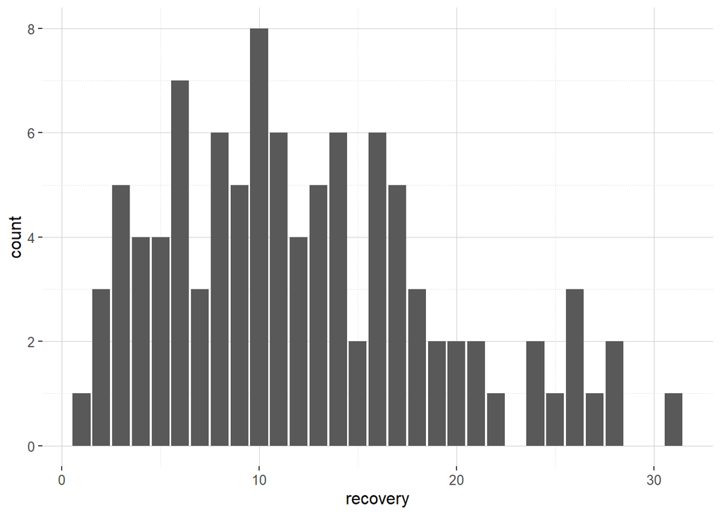

```r
recovered %>%
  ggplot(aes(x = recovery)) +
  geom_bar()
```

2. Is there a difference in the time it took to recover for different ages?
   - Create a new variable `age_blks` from `age` that introduces age categories that groups the ages of the patients into intervals: < 10, 10-20, 20-30, 30-40, 40-50, 50-60, 60-70, 70-80, and >80. (see ?cut).
   - Create side-by-side boxplots of the number of days to recovery for the different age groups.
   - Flip the coordinates and map the variable `age_blks` to the fill aesthetic.

```r
recovered2 <- recovered %>%
  group_by(age) %>%
  mutate(age_blks = cut(age, breaks = c(0, 10, 20, 30, 40, 50, 60, 70, 80, 90),
      labels = c("0-10", "10-20", "20-30", "30-40", "40-50", "50-60", "60-70", "70-80", "80+")))
```

3. Is there a difference between the genders in the time it took to recover for any of the groups?
   - Use the age blocks created in the last question.
   - Create side-by-side boxplots for males and females (1’s and 0’s, respectively) for each of the age groups.
   - Fill your boxplots by mapping the variable `gender` to the aesthetic `fill`.

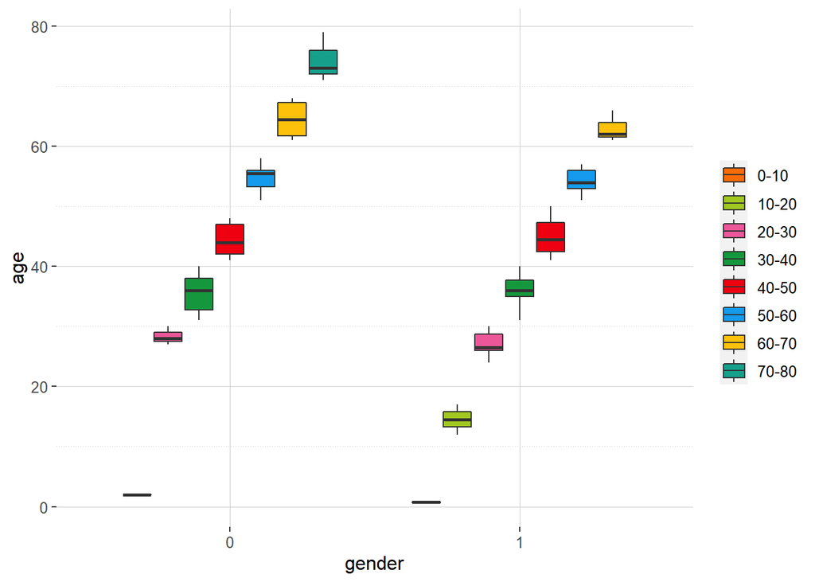

```r
recovered2 <- mutate_at(recovered2, vars(gender), as.character)
recovered2 %>%
  group_by(gender) %>%
  ggplot(aes(x = gender, y = age, fill = age_blks)) + geom_boxplot()
```